# Cuestionario 2 · Manipulación de bases de datos

Bioestadística · Semana 3 · 2026-II

Autor/a

Fecha de publicación

19 de octubre de 2026

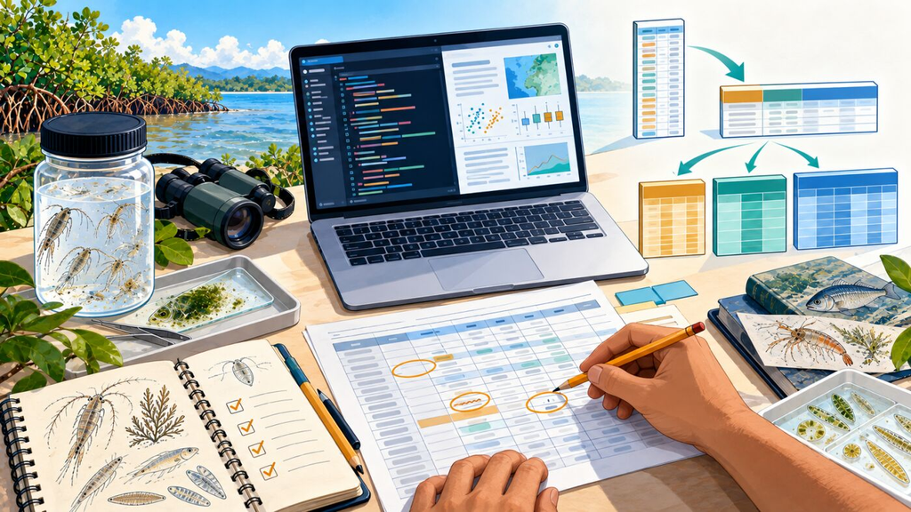

## Instrucciones

- **Entrega:** el archivo `.qmd` ejecutado y su render en HTML, en la actividad «E3 · Cuestionario Quarto CQ1 · Manipulación» de Moodle. **Cierra el martes 27 de octubre a las 23:59.**
- El documento debe renderizar sin errores desde los archivos de datos (`plancton.xlsx`, `Microalgas.xlsx` y `Microalgas.csv`) ubicados en la misma carpeta, sin pasos manuales. Los archivos de datos no se editan: toda corrección se hace en el código.
- Cada pregunta se responde con **código propio comentado** (un comentario `# …` antes de cada bloque) y una **respuesta escrita** en el espacio «Respuesta». La respuesta debe explicar qué se hizo y **por qué** (por qué se agrega, por qué se pasa a formato ancho, por qué se transforma), no solo describir la salida.
- Los valores que se mencionen en las respuestas deben salir del propio código.
- Columnas siempre **por nombre**, no por posición.

[Descargar materiales del cuestionario](https://javier-2712.github.io/Manuales/8.Manual_diseno_msc/talleres_complemento/taller5/cuestionario2_taller5.zip)

**Nota:** descomprimir el **.zip** para poderlo trabajar en R

**NotaCriterios de la rúbrica R2**

| Criterio | Puntos |
| --- | --- |
| 1. Reproducibilidad: renderiza limpio desde los datos y el código está comentado | 10 |
| 2. Respuestas correctas, obtenidas con el propio código | 20 |
| 3. Interpretación de decisiones: qué hace cada paso y por qué | 10 |
| **Total** | **40** |

## Preparación (resuelta)

El siguiente bloque carga las librerías y la tabla de zonas del plancton, igual que en el Taller 5; no se modifica.

**Código**

```r
# Librerías
library(tidyverse)
library(readxl)
library(writexl)
library(kableExtra)
library(vegan)

# Zonas de las estaciones del estuario (Vargas-Ospina y Córdoba-Bejarano, 2022)
zonas <- tibble(Station = factor(c(2, 4, 7, 9, 13, 15)),
                Zona    = factor(rep(c("Fluvial", "Estuarina", "Marina"), each = 2),
                                 levels = c("Fluvial", "Estuarina", "Marina")))
```

## Sección A — Lectura y depuración

### Pregunta 1 · Leer un CSV en formato español

Lea `Microalgas.csv` con la función adecuada a su formato. Muestre con código que las variables ambientales quedaron como números y compruebe que la lectura coincide con `Microalgas.xlsx`.

*Explique:* ¿qué dos características del archivo determinan la función de lectura y qué ocurre si se usa `read_csv()`?

**Código**

```r
# Escriba aquí su código (comente cada bloque con # …)
```

**Respuesta:**

### Pregunta 2 · Espacios sobrantes

Lea la hoja `Riqueza` de `plancton.xlsx` y el encabezado de `Microalgas.csv` **sin recortar espacios** e identifique con código qué valores o nombres terminan en espacio. Cuente cuántas filas devuelve un filtro por «Quetognatos» antes y después de corregir.

*Explique:* ¿por qué conviene corregir con `str_trim()` en el código, aunque `read_excel()` recorte espacios por defecto?

**Código**

```r
# Escriba aquí su código (comente cada bloque con # …)
```

**Respuesta:**

### Pregunta 3 · Nombres y matrices F, X y Y

A partir de `Microalgas.xlsx`, corrija los cinco nombres de género mal escritos, cree la variable `Visita` a partir de `Cod` y separe las matrices `F_alg` (Cod, Tributario, Visita), `X_alg` (10 variables ambientales) y `Y_alg` (21 géneros) **por nombre de columna**. Verifique con código que las tres tienen las mismas filas y muestre la fila de la muestra T2.4 con amonio, oxígeno, *Fragilaria* y *Melosira*.

*Explique:* ¿por qué se seleccionan las columnas por nombre y qué error se cometería si se ordenara `Y_alg` por separado?

**Código**

```r
# Escriba aquí su código (comente cada bloque con # …)
```

**Respuesta:**

## Sección B — Verbos y resúmenes

### Pregunta 4 · Resumen por grupo

Con las matrices de la Pregunta 3, calcule la abundancia total y la riqueza de géneros de cada muestra. Presente una tabla por tributario con n, media, desviación estándar, error estándar, mediana y coeficiente de variación de la abundancia total.

*Explique:* ¿qué informa el e.e. y qué la d.e.? ¿Qué tributario es más variable en términos relativos?

**Código**

```r
# Escriba aquí su código (comente cada bloque con # …)
```

**Respuesta:**

### Pregunta 5 · Agrupar sin resumir

Identifique las visitas en que la temperatura superó la media de su propio tributario y cuente cuántas hay por tributario.

*Explique:* ¿por qué se usa `group_by()` con `filter()` y no con `summarise()`?

**Código**

```r
# Escriba aquí su código (comente cada bloque con # …)
```

**Respuesta:**

## Sección C — Formatos largo y ancho

### Pregunta 6 · Otra unidad de agregación

Con la hoja `Riqueza` depurada (espacios, factores y capas en español, como en el Taller 5), construya una base ancha con **una fila por estación × capa** (sumando las dos mallas), con las variables ambientales promediadas, un taxón por columna y la abundancia total `Ab`. Agregue la zona con `left_join()` y verifique el número de filas y la ausencia de `NA`.

*Explique:* ¿por qué se suman las abundancias y se promedian las variables ambientales? ¿Qué se pierde al sumar las dos mallas en una sola muestra?

**Código**

```r
# Escriba aquí su código (comente cada bloque con # …)
```

**Respuesta:**

### Pregunta 7 · De ancho a largo

Pase `Y_alg` (con `F_alg`) a formato largo. Identifique los **cinco géneros más abundantes**, su porcentaje del total y, para cada uno, el tributario donde alcanza su mayor abundancia total.

*Explique:* ¿por qué conviene el formato largo para este cálculo?

**Código**

```r
# Escriba aquí su código (comente cada bloque con # …)
```

**Respuesta:**

### Pregunta 8 · Réplicas y épocas

Lea la hoja `Abundancia` de `plancton.xlsx`, armonice los nombres y factores con la hoja `Riqueza` (`Stations` → `Station`; capas y épocas en español) e identifique las réplicas. Construya una base ancha con **una columna por época** (Lluvias y Seca) y una fila por estación × capa × malla × réplica. Agregue la zona y presente la densidad media por zona y época.

*Explique:* ¿por qué hace falta numerar las réplicas antes de `pivot_wider()`? ¿Las densidades de las réplicas se suman o se promedian?

**Código**

```r
# Escriba aquí su código (comente cada bloque con # …)
```

**Respuesta:**

## Sección D — Categorización y transformaciones

### Pregunta 9 · Terciles a nivel de unidad muestral

Categorice el oxígeno disuelto de las microalgas en terciles (Bajo, Medio, Alto) a nivel de muestra, presente el número de muestras por clase y crúcelo con el tributario. Compare con el mismo cruce para la conductividad.

*Explique:* ¿cuál de las dos variables categorizadas podría usarse como un factor distinto del tributario y por qué?

**Código**

```r
# Escriba aquí su código (comente cada bloque con # …)
```

**Respuesta:**

### Pregunta 10 · Transformar, guardar y reportar

Estandarice `X_alg` y compruebe medias y desviaciones estándar. Transforme `Y_alg` con Hellinger y compare el porcentaje que representa *Cocconeis* en la matriz cruda y en la transformada. Calcule la proporción de ceros de `Y_alg`. Guarde en un libro de Excel las hojas F, X estandarizada y Y transformada.

*Explique:* ¿por qué se estandariza X y por qué se transforma Y? Redacte un párrafo de métodos (3 a 5 líneas) como el del recuadro «Cómo reportar el resultado» del Taller 5.

**Código**

```r
# Escriba aquí su código (comente cada bloque con # …)
```

**Respuesta:**